[figure not shown]

[figure not shown]

# Read in data

### Read data

Below we

- read in data
- create a log-transformed version of the response
- create a factor version of **hour**

```r
data <- read.table("../data/hydrolysis.txt",header=T)
data$logserine <- log10(data$serine)
data$hourfac <- factor(data$hour)
levels(data$feed)
```

```
[1] "barley" "fish"   "mais"   "meat"   "soy"
```

```r
dim(data)
```

```
[1] 50  5
```

```r
head(data)
```

```
    feed hour serine logserine hourfac
1 barley    8   4.47 0.6503075       8
2 barley   16   4.34 0.6374897      16
3 barley   24   4.22 0.6253125      24
4 barley   32   4.10 0.6127839      32
5 barley   72   3.48 0.5415792      72
6 barley    8   4.46 0.6493349       8
```

### Tables

```r
table(data$feed)
```

```
barley   fish   mais   meat    soy
    10     10     10     10     10
```

```r
table(data$hourfac)
```

```
 8 16 24 32 72
10 10 10 10 10
```

```r
table(data$feed, data$hourfac)
```

```
         8 16 24 32 72
  barley 2  2  2  2  2
  fish   2  2  2  2  2
  mais   2  2  2  2  2
  meat   2  2  2  2  2
  soy    2  2  2  2  2
```

# 2-way analysis of variance

### Interaction

Test for interaction between **feed** and **hour** (used as a factor) in the model

```r
model1 <- lm(logserine ~ feed:hourfac,data)
model2 <- lm(logserine ~ feed + hourfac,data)
anova(model2, model1)
```

```
Analysis of Variance Table

Model 1: logserine ~ feed + hourfac
Model 2: logserine ~ feed:hourfac
  Res.Df        RSS Df  Sum of Sq      F Pr(>F)
1     41 0.00076722
2     25 0.00050543 16 0.00026179 0.8093 0.6643
```

No significant interacction between factors **feed** and **hour**.

### Main effects

The following R code demonstrates that both main effects explains a significant amount of the variation in the data.

```r
model4 <- lm(logserine ~ feed,data)
anova(model4, model2)
```

```
Analysis of Variance Table

Model 1: logserine ~ feed
Model 2: logserine ~ feed + hourfac
  Res.Df      RSS Df Sum of Sq      F    Pr(>F)
1     45 0.078457
2     41 0.000767  4   0.07769 1037.9 < 2.2e-16 ***
---
Signif. codes:  0 '***' 0.001 '**' 0.01 '*' 0.05 '.' 0.1 ' ' 1
```

```r
model5 <- lm(logserine ~ hourfac,data)
anova(model5, model2)
```

```
Analysis of Variance Table

Model 1: logserine ~ hourfac
Model 2: logserine ~ feed + hourfac
  Res.Df      RSS Df Sum of Sq      F    Pr(>F)
1     45 0.121412
2     41 0.000767  4   0.12065 1611.8 < 2.2e-16 ***
---
Signif. codes:  0 '***' 0.001 '**' 0.01 '*' 0.05 '.' 0.1 ' ' 1
```

### Estimates

Parameter estimates for additive model given below. Test yourself be answering the following questions

- what does the estimate labeled *(Intercept)* describe?
- what is the expected value of $log_{10}({\tt serine})$ for an observation with **feed = barley** and **hour = 16**?
- what is the expected difference between $log_{10}({\tt serine})$ for observations with **feed = barley** and **feed = fish** when **hour = 24**?

```r
summary(model2)
```

```
Call:
lm(formula = logserine ~ feed + hourfac, data = data)

Residuals:
       Min         1Q     Median         3Q        Max
-0.0106117 -0.0026701 -0.0005554  0.0026400  0.0083471

Coefficients:
             Estimate Std. Error t value Pr(>|t|)
(Intercept)  0.652197   0.001835 355.365  < 2e-16 ***
feedfish    -0.028801   0.001935 -14.888  < 2e-16 ***
feedmais     0.068618   0.001935  35.469  < 2e-16 ***
feedmeat    -0.008051   0.001935  -4.161 0.000158 ***
feedsoy      0.099552   0.001935  51.460  < 2e-16 ***
hourfac16   -0.013941   0.001935  -7.206 8.44e-09 ***
hourfac24   -0.026159   0.001935 -13.522  < 2e-16 ***
hourfac32   -0.042652   0.001935 -22.047  < 2e-16 ***
hourfac72   -0.112769   0.001935 -58.292  < 2e-16 ***
---
Signif. codes:  0 '***' 0.001 '**' 0.01 '*' 0.05 '.' 0.1 ' ' 1

Residual standard error: 0.004326 on 41 degrees of freedom
Multiple R-squared:  0.9961,    Adjusted R-squared:  0.9954
F-statistic:  1325 on 8 and 41 DF,  p-value: < 2.2e-16
```

# Plot data

### Standard graphics - code

```r
plot(data$hour, data$logserine
     , xlab = "Time / hours", ylab = "log10(serine)", cex.lab = 1.25
     , main = "Example 4.2: hydrolysis of amino acid", cex.main = 1.25
     , pch = as.numeric(data$feed), col = as.numeric(data$feed), cex = 1.3
     , xlim = c(0, 72))
legend(55, 0.75, legend=levels(data$feed), bty = "n", pch = 1:5, col = 1:5, cex = 1.3)
```

### Standard graphics - plot

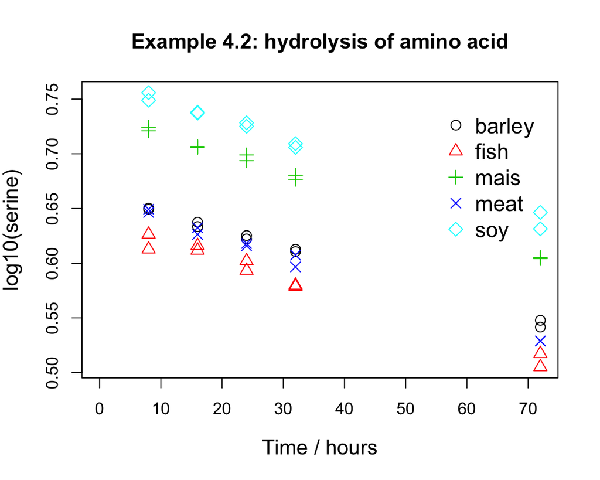

It seems reasonable to assume that there is a linear relationship between **log(serine)** and the numeric variable **hour**.

### ggplot2 - kode

Cool plot using the R package **ggplot2**

- `ggplot(data = data)`: variables from data.frame called `data` are used for plot
- `geom_point()`: we want to create a scatter plot
- `aes()` maps *aestetics* of a scatter plot to varibles in the data.frame
  - **hour** on the x-axis
  - **logserine** on the y-axis
  - **color** points according to **feed**
  - use individual point **shape** for each level of factor **feed**

```r
library(ggplot2)
ggplot(data = data) + geom_point(mapping = aes(x = hour, y = logserine, color = feed, shape = feed))
```

### ggplot2 - figur

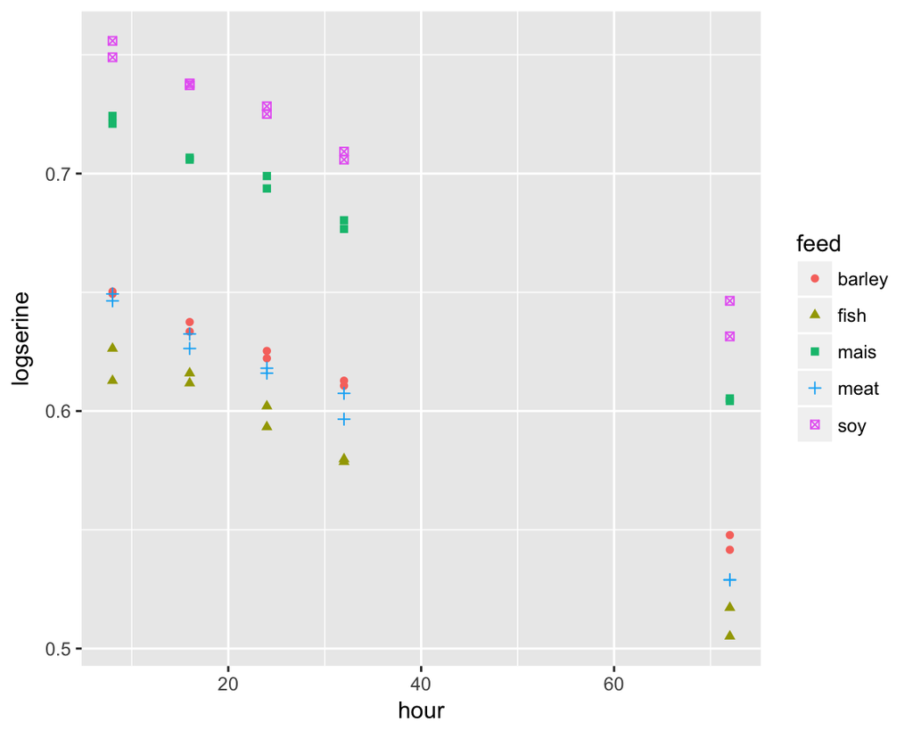

# Analysis of covariance

### hour as covariate

The following models all use the numeric version **hour** of the time variable. In particular, all models assume a linear relationship between **hour** and the response variable **log(serine)**.

Make sure that you understand the difference between the models

- **model6**: intercept and slope parameter of the linear relationship depend on **feed**
- **model3**: intercept parameter of the linear relations depend on **feed**, but slope parameters are the same for all levels of **feed**
- **model7**: intercept and slope parameter of the linear relationship are the same for all levels of **feed**

```r
model3 <- lm(logserine ~ feed + hour,data)
model6 <- lm(logserine ~ feed + hour + feed:hour - 1,data)
model7 <- lm(logserine ~ hour,data)
```

### model6

```r
summary(model6)
```

```
Call:
lm(formula = logserine ~ feed + hour + feed:hour - 1, data = data)

Residuals:
       Min         1Q     Median         3Q        Max
-0.0107562 -0.0020415  0.0002108  0.0020884  0.0077246

Coefficients:
                Estimate Std. Error t value Pr(>|t|)
feedbarley     6.628e-01  2.181e-03 303.939   <2e-16 ***
feedfish       6.376e-01  2.181e-03 292.356   <2e-16 ***
feedmais       7.377e-01  2.181e-03 338.259   <2e-16 ***
feedmeat       6.608e-01  2.181e-03 303.035   <2e-16 ***
feedsoy        7.667e-01  2.181e-03 351.574   <2e-16 ***
hour          -1.636e-03  5.785e-05 -28.272   <2e-16 ***
feedfish:hour -1.165e-04  8.182e-05  -1.424   0.1622
feedmais:hour -2.048e-04  8.182e-05  -2.503   0.0165 *
feedmeat:hour -2.000e-04  8.182e-05  -2.444   0.0190 *
feedsoy:hour  -1.424e-04  8.182e-05  -1.740   0.0896 .
---
Signif. codes:  0 '***' 0.001 '**' 0.01 '*' 0.05 '.' 0.1 ' ' 1

Residual standard error: 0.004077 on 40 degrees of freedom
Multiple R-squared:      1, Adjusted R-squared:      1
F-statistic: 1.241e+05 on 10 and 40 DF,  p-value: < 2.2e-16
```

### model 3

```r
summary(model3)
```

```
Call:
lm(formula = logserine ~ feed + hour, data = data)

Residuals:
      Min        1Q    Median        3Q       Max
-0.011119 -0.002560 -0.000373  0.002341  0.008247

Coefficients:
              Estimate Std. Error t value Pr(>|t|)
(Intercept)  0.6668516  0.0015819 421.540  < 2e-16 ***
feedfish    -0.0288013  0.0019099 -15.080  < 2e-16 ***
feedmais     0.0686175  0.0019099  35.928  < 2e-16 ***
feedmeat    -0.0080505  0.0019099  -4.215 0.000122 ***
feedsoy      0.0995522  0.0019099  52.125  < 2e-16 ***
hour        -0.0017684  0.0000271 -65.253  < 2e-16 ***
---
Signif. codes:  0 '***' 0.001 '**' 0.01 '*' 0.05 '.' 0.1 ' ' 1

Residual standard error: 0.004271 on 44 degrees of freedom
Multiple R-squared:  0.996, Adjusted R-squared:  0.9955
F-statistic:  2175 on 5 and 44 DF,  p-value: < 2.2e-16
```

### model 7

```r
summary(model7)
```

```
Call:
lm(formula = logserine ~ hour, data = data)

Residuals:
     Min       1Q   Median       3Q      Max
-0.06618 -0.03687 -0.02660  0.04362  0.08061

Coefficients:
              Estimate Std. Error t value Pr(>|t|)
(Intercept)  0.6931152  0.0120319   57.61  < 2e-16 ***
hour        -0.0017684  0.0003192   -5.54 1.25e-06 ***
---
Signif. codes:  0 '***' 0.001 '**' 0.01 '*' 0.05 '.' 0.1 ' ' 1

Residual standard error: 0.0503 on 48 degrees of freedom
Multiple R-squared:   0.39, Adjusted R-squared:  0.3773
F-statistic: 30.69 on 1 and 48 DF,  p-value: 1.254e-06
```

### Test of linearity

We can make a formal test for the linearity assumption between **log(serine)** and **hour** by comparing with a model, where the factor version **hourfac** of time is included in the model.

```r
anova(model3,model2)
```

```
Analysis of Variance Table

Model 1: logserine ~ feed + hour
Model 2: logserine ~ feed + hourfac
  Res.Df        RSS Df  Sum of Sq      F Pr(>F)
1     44 0.00080247
2     41 0.00076722  3 3.5247e-05 0.6279 0.6012
```

It turns out (check for yourself!) that neither **hour** nor **feed** can be removed from **model3**.

### Parameter estimates (1)

The model (**model3**) expresses that there is a linear relationship between **log(serine)** and **hour**. The slope parameter is the same for all levels of factor **feed** but the intercept parameters differ.

Make sure that the understand the parametrisation used in the R output

```r
summary(model3)
```

```
Call:
lm(formula = logserine ~ feed + hour, data = data)

Residuals:
      Min        1Q    Median        3Q       Max
-0.011119 -0.002560 -0.000373  0.002341  0.008247

Coefficients:
              Estimate Std. Error t value Pr(>|t|)
(Intercept)  0.6668516  0.0015819 421.540  < 2e-16 ***
feedfish    -0.0288013  0.0019099 -15.080  < 2e-16 ***
feedmais     0.0686175  0.0019099  35.928  < 2e-16 ***
feedmeat    -0.0080505  0.0019099  -4.215 0.000122 ***
feedsoy      0.0995522  0.0019099  52.125  < 2e-16 ***
hour        -0.0017684  0.0000271 -65.253  < 2e-16 ***
---
Signif. codes:  0 '***' 0.001 '**' 0.01 '*' 0.05 '.' 0.1 ' ' 1

Residual standard error: 0.004271 on 44 degrees of freedom
Multiple R-squared:  0.996, Adjusted R-squared:  0.9955
F-statistic:  2175 on 5 and 44 DF,  p-value: < 2.2e-16
```

```r
confint(model3)
```

```
                   2.5 %       97.5 %
(Intercept)  0.663663444  0.670039831
feedfish    -0.032650345 -0.024952192
feedmais     0.064768451  0.072466604
feedmeat    -0.011899586 -0.004201433
feedsoy      0.095703138  0.103401291
hour        -0.001823011 -0.001713775
```

### Parameter estimates (2)

```r
10^(coef(model3))
```

```
(Intercept)    feedfish    feedmais    feedmeat     feedsoy        hour
  4.6435662   0.9358338   1.1711635   0.9816338   1.2576280   0.9959364
```

```r
10^(confint(model3))
```

```
                2.5 %    97.5 %
(Intercept) 4.6096022 4.6777804
feedfish    0.9275763 0.9441648
feedmais    1.1608295 1.1815894
feedmeat    0.9729722 0.9903725
feedsoy     1.2465312 1.2688237
hour        0.9958112 0.9960617
```

Backtransformed estimates should be interpreted as relative changes

- increasing **hour** by one unit leads to a decrease by a factor 0.9959 (= 0.41 %) of **serine**
- the relative difference between **feed=fish** and **feed=barley** (used as reference/Intercept by R) is 0.9358 implying that serine content are 100 x (1 - 0.9358) = 6.42 % lower in **fish** compared to **barley**

### Parameter estiamtes (3)

```r
model3alt <- lm(logserine ~ relevel(feed, ref = "fish") + hour,data)
summary(model3alt)
```

```
Call:
lm(formula = logserine ~ relevel(feed, ref = "fish") + hour,
    data = data)

Residuals:
      Min        1Q    Median        3Q       Max
-0.011119 -0.002560 -0.000373  0.002341  0.008247

Coefficients:
                                    Estimate Std. Error t value Pr(>|t|)
(Intercept)                        0.6380504  0.0015819  403.33  < 2e-16
relevel(feed, ref = "fish")barley  0.0288013  0.0019099   15.08  < 2e-16
relevel(feed, ref = "fish")mais    0.0974188  0.0019099   51.01  < 2e-16
relevel(feed, ref = "fish")meat    0.0207508  0.0019099   10.87 4.86e-14
relevel(feed, ref = "fish")soy     0.1283535  0.0019099   67.21  < 2e-16
hour                              -0.0017684  0.0000271  -65.25  < 2e-16

(Intercept)                       ***
relevel(feed, ref = "fish")barley ***
relevel(feed, ref = "fish")mais   ***
relevel(feed, ref = "fish")meat   ***
relevel(feed, ref = "fish")soy    ***
hour                              ***
---
Signif. codes:  0 '***' 0.001 '**' 0.01 '*' 0.05 '.' 0.1 ' ' 1

Residual standard error: 0.004271 on 44 degrees of freedom
Multiple R-squared:  0.996, Adjusted R-squared:  0.9955
F-statistic:  2175 on 5 and 44 DF,  p-value: < 2.2e-16
```

```r
confint(model3alt)
```

```
                                         2.5 %       97.5 %
(Intercept)                        0.634862176  0.641238563
relevel(feed, ref = "fish")barley  0.024952192  0.032650345
relevel(feed, ref = "fish")mais    0.093569720  0.101267872
relevel(feed, ref = "fish")meat    0.016901682  0.024599835
relevel(feed, ref = "fish")soy     0.124504407  0.132202560
hour                              -0.001823011 -0.001713775
```